# Proyecto Genómica

Mayela Fosado

1/6/2022

# **Variabilidad en el genoma mitocondrial humano en personas sanas**

## **Introducción**

En el genoma mitocondrial humano existen mutuaciones puntuales, deleciones e inserciones (indels), los cuales son causa de una gran variedad de enfermedades debilitantes y frecuentemente fatales, que ocurren con una prevalencia mínima de 1:3500, entre estas destacan enfermedades neuromusculares, encelopatías como la neuropatía óptica hereditaria de Leber, síndrome MELAS, síndrome Kearns-Sayre, síndrome de Leigh y diabetes con sordera.

Un punto de debate activo en este es si las mutaciones se generan desde etapas juveniles o solamente durante la vejez.

## **Objetivo**

El objetivo de este proyecto es analizar la variabilidad en el genoma mitocondrial humano en personas sanas.

## **Metodología**

Para el análisis de la carga de variantes en el genoma mitocondrial de placenta humana se obtuvieron muestras en colaboración con la Clínica CER, ubicada en el Corregidora, Querétaro. y la UNAM. Se seleccionó este tejido por ser una fuente accesible y abundante de tejido humano y se obtuvo por medio de cesáreas de embarazos sanos.

Las muestras obtenidas se obtuvieron consentimiento informado y de acuerdo al Protocolo 44.H del Cómite de Ética en la Investigación del Instituto de Neurobiología.

Las secuencias se obtuvieron en un equipo Illumina NexSeq 550 en Duke University.

Para el análisis de las muestras se utiizaron las herramientas fastQC, trimmomatic, segemehl, samtools y mutec2. Los datos de las secuencias fueron proporcionados por el Dr. Alfredo Varela y se encuentran en el servidor de la UNAM, en la ruta de trabajo del mismo. Las muestras abarcan de BC50 a BC58, con excepción de BC53.

### **FastQC**

Se utilizó para revisar el análisis de calidad de las secuencias, y se añadieron los html’s con la información contenida en la misma carpeta del proyecto.

Archivos html fastqc https://github.com/Mayfm/Genomic/tree/main/Proyecto/fastq_html

En este html solo se pondrá un job (script) de cada muestra como ejemplo, al igual que los html’s los demás se encuentran en la carpeta.

```
#$ -S /bin/bash

#

# Nombre

#$ -N fastQC

#
# Utilizar el directorio donde está el archivo
#$ -cwd
#
# Unir stdout and stderr
#$ -j y
#
# Enviar un correo cuando esté listo el job
#$ -m e
#$ -M maye.fosado@gmail.com
#
# Si se necesitan módulos, el entorno de los módulos de origen
. /etc/profile.d/modules.sh
#
# Agregar módulos necesarios
module load fastqc/0.11.3
#
#A continuación, número de hilos pedidos a máquina
#$ -pe mpich 1
#
# Comandos
fastqc /mnt/Timina/alfredvar/alfredvar/seqdata/SENASICA_7/BC50_S37_R1_001.fastq
```

### **Trimmomatic**

Eliminar secuencias de baja calidad y recortar extremos de baja calidad.

```
#$ -S /bin/bash

#

# Nombre

#$ -N trimm.B

#
# Use current working directory
#$ -cwd
#
# Join stdout and stderr
#$ -j y
#
#
# If modules are needed, source modules environment (Do not delete the next line):
. /etc/profile.d/modules.sh
#
# Add any modules you might require:
module load trimmomatic/0.33
#
#pe (Parallel environment)request a parallel environment (MPI, OpenMP). Set your number of requested slots here.
#A continuación, número de hilos pedidos a máquina
#$ -pe mpich 1
#
# Write your commands in the next line

trimmomatic PE -trimlog trimlog.BC50 BC50_S37_R1_001.fastq BC50_S37_R2_001.fastq BC50_R1_trimP.fastq BC50_R1_trimU.fastq BC50_R2_trimP.fastq BC50_R2_trimU.fastq HEADCROP:9
trimmomatic PE -trimlog trimlog.BC51 BC51_S38_R1_001.fastq BC51_S38_R2_001.fastq BC51_R1_trimP.fastq BC51_R1_trimU.fastq BC51_R2_trimP.fastq BC51_R2_trimU.fastq HEADCROP:9
trimmomatic PE -trimlog trimlog.BC52 BC52_S39_R1_001.fastq BC52_S39_R2_001.fastq BC52_R1_trimP.fastq BC52_R1_trimU.fastq BC52_R2_trimP.fastq BC52_R2_trimU.fastq HEADCROP:9
trimmomatic PE -trimlog trimlog.BC54 BC54_S41_R1_001.fastq BC54_S41_R2_001.fastq BC54_R1_trimP.fastq BC54_R1_trimU.fastq BC54_R2_trimP.fastq BC54_R2_trimU.fastq HEADCROP:9
trimmomatic PE -trimlog trimlog.BC55 BC55_S42_R1_001.fastq BC55_S42_R2_001.fastq BC55_R1_trimP.fastq BC55_R1_trimU.fastq BC55_R2_trimP.fastq BC55_R2_trimU.fastq HEADCROP:9
trimmomatic PE -trimlog trimlog.BC56 BC56_S43_R1_001.fastq BC56_S43_R2_001.fastq BC56_R1_trimP.fastq BC56_R1_trimU.fastq BC56_R2_trimP.fastq BC56_R2_trimU.fastq HEADCROP:9
trimmomatic PE -trimlog trimlog.BC57 BC57_S44_R1_001.fastq BC57_S44_R2_001.fastq BC57_R1_trimP.fastq BC57_R1_trimU.fastq BC57_R2_trimP.fastq BC57_R2_trimU.fastq HEADCROP:9
trimmomatic PE -trimlog trimlog.BC58 BC58_S45_R1_001.fastq BC58_S45_R2_001.fastq BC58_R1_trimP.fastq BC58_R1_trimU.fastq BC58_R2_trimP.fastq BC58_R2_trimU.fastq HEADCROP:9
```

*PE*: lecturas pareadas, en caso de que fuera simple se coloca SE.

### **Segemehl**

Alineamiento de secuencias al genoma de referencia. El genoma de referencia se obtuvo de la UCSC.

Ya que el genoma de mitocondria es circular se enlazaron 3kb de la cabeza y 3 kb de la cola. Se realizaron las muestras con el genoma completo y con los dos extremos que fueron unidos.

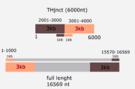

Previamente se realizan índices con el genoma de referencia.

```
module load segemehl/0.3.4

# Secuencia completa
segemehl.x -x chrM.hg38A.idx -d chrM.hg38A.fa

# Extremos
segemehl.x -x chrM.hg38.THjnct.idx -d chrM.hg38.THjnct.fa
```

Con la secuencia completa.

```
#$ -S /bin/bash
#
# Your job name
#$ -N BC54.bam
#
# Use current working directory
#$ -cwd
#
# Join stdout and stderr
#$ -j y
#
# If modules are needed, source modules environment (Do not delete the next line):
. /etc/profile.d/modules.sh
#
# Agregar módulos necesarios
module load segemehl/0.3.4
#
#pe (Parallel environment)request a parallel environment (MPI, OpenMP). Set your number of requested slots here.
#A continuación, número de hilos pedidos a máquina
#$ -pe mpich 8
#
# Write your commands in the next line
segemehl.x -b -S -t 8 -g RGmt -d chrM.hg38A.fa -i chrM.hg38A.idx -q /mnt/Timina/alfredvar/alfredvar/seqdata/SENASICA_7/BC50_R1_trimP.fastq -p /mnt/Timina/alfredvar/alfredvar/seqdata/SENASICA_7/BC50_R2_trimP.fastq > BC50A.bam
```

Con los extremos.

```
#$ -S /bin/bash
#
# Your job name
#$ -N BC50j
#
# Use current working directory
#$ -cwd
#
# Join stdout and stderr
#$ -j y
#
# If modules are needed, source modules environment (Do not delete the next line):
. /etc/profile.d/modules.sh
#
# Agregar módulos necesarios
module load segemehl/0.3.4
#
#A continuación, número de hilos pedidos a máquina
#$ -pe mpich 8
#
# Comandos
segemehl.x -S -b -t 8 -g RGmt -d chrM.hg38.THjnct.fa -i chrM.hg38.THjnct.idx -q /mnt/Timina/alfredvar/alfredvar/seqdata/SENASICA_7/BC50_R1_trimP.fastq -p /mnt/Timina/alfredvar/alfredvar/seqdata/SENASICA_7/BC50_R2_trimP.fastq -o BC50j.bam
```

*-s* modo de lecturas divididas *-b* en formato bam *-t* número de hilos, 8 en este caso *-d* base de datos, indica que ahí están los datos (genoma de referencia) *-i* índice *-q* primer archivo, sec query *-p* segundo archivo

### **Samtools**

Para el análisis y manejo de los datos. Lectura, edición, index, visualización de formatos SAM, BAM, CRAM.

```
#$ -S /bin/bash

#

# Your job name

#$ -N samtools.B

#
# Use current working directory
#$ -cwd
#
# Join stdout and stderr
#$ -j y
#
#
# If modules are needed, source modules environment (Do not delete the next line):
. /etc/profile.d/modules.sh
#
# Agregar módulos necesarios
module load samtools/1.3.1
#
#pe (Parallel environment)request a parallel environment (MPI, OpenMP). Set your number of requested slots here.
#A continuación, número de hilos pedidos a máquina
#$ -pe mpich 1
#
# Write your commands in the next line
samtools sort BC50A.bam -o BC50A.bam.sort
samtools sort BC50.j.bam -o BC50.j.bam.sort
samtools sort BC51A.bam -o BC51A.bam.sort
samtools sort BC51.j.bam -o BC51.j.bam.sort
samtools sort BC52A.bam -o BC52A.bam.sort
samtools sort BC52.j.bam -o BC52.j.bam.sort
samtools sort BC54A.bam -o BC54A.bam.sort
samtools sort BC54.j.bam -o BC54.j.bam.sort
samtools sort BC55A.bam -o BC55A.bam.sort
samtools sort BC55.j.bam -o BC55.j.bam.sort
samtools sort BC56A.bam -o BC56A.bam.sort
samtools sort BC56.j.bam -o BC56.j.bam.sort
samtools sort BC57A.bam -o BC57A.bam.sort
samtools sort BC57.j.bam -o BC57.j.bam.sort
samtools sort BC58A.bam -o BC58A.bam.sort
samtools sort BC58.j.bam -o BC58.j.bam.sort
```

### **Mutec2**

Identifación de variantes

Llamado de mutaciones cortas somáticas por medio del ensamblaje de haplotipos, incluyen alteraciones de un solo nucleótido (SNA), de inserción y deleción. Existen 3 tipos de modos:

1. Modo tumor-normal, una muestra de tumor se empareja con una muestra normal.
2. Modo solo tumor, solo los datos de una muestra se someten a análisis.
3. Modo mitocondrial, en este caso el modo de interés.

Con la secuencia completa.

```
#$ -S /bin/bash
#
# Your job name
#$ -N BC50A.mt2
#
# Use current working directory
#$ -cwd
#
# Join stdout and stderr
#$ -j y
#
# If modules are needed, source modules environment (Do not delete the next line):
. /etc/profile.d/modules.sh
#
# Agregar módulos necesarios
module load gatk/4.1.6.0
#
#pe (Parallel environment)request a parallel environment (MPI, OpenMP). Set your
number of requested slots here.
#A continuación, número de hilos pedidos a máquina
#$ -pe mpich 4
#
# Write your commands in the next line
gatk Mutect2 \
-R chrM.hg38A.fa \
-I BC50A.bam.sort \
-O BC50A.vcf.gz \
-L chrM \
--mitochondria-mode \
--active-probability-threshold 0.000001 \
--base-quality-score-threshold 6 \
--callable-depth 5 \
--downsampling-stride 1 \
--f1r2-max-depth 1000000 \
--force-active \
--max-mnp-distance 0 \
--max-population-af 1 \
--max-reads-per-alignment-start 0 \
--min-base-quality-score 30 \
--dont-use-soft-clipped-bases \
--phred-scaled-global-read-mismapping-rate 30
```

Con los extremos.

```
#$ -S /bin/bash
#
# Your job name
#$ -N BC50j.mt2
#
# Use current working directory
#$ -cwd
#
# Join stdout and stderr
#$ -j y
#
# If modules are needed, source modules environment (Do not delete the next line):
. /etc/profile.d/modules.sh
#
# Agregar módulos necesarios
module load gatk/4.1.6.0
#
#pe (Parallel environment)request a parallel environment (MPI, OpenMP). Set your
number of requested slots here.
#A continuación, número de hilos pedidos a máquina
#$ -pe mpich 4
#
# Write your commands in the next line
gatk Mutect2 \
-R chrM.hg38.THjnct.fa \
-I BC50.j.bam.sort \
-O BC50j.vcf.gz \
-L chrM:1500-4500 \
--mitochondria-mode \
--active-probability-threshold 0.000001 \
--base-quality-score-threshold 6 \
--callable-depth 5 \
--downsampling-stride 1 \
--f1r2-max-depth 1000000 \
--force-active \
--max-mnp-distance 0 \
--max-population-af 1 \
--max-reads-per-alignment-start 0 \
--min-base-quality-score 30 \
--dont-use-soft-clipped-bases \
--phred-scaled-global-read-mismapping-rate 30
```

*-R* genoma de referencia *-I* archivo de entrada *-O* archivo de salida *–active-probability-threshold* probabilidad mínima para que un locus se considere activo *–downsampling-stride* reducir la muestra de un conjunto de lecturas que comienzan en un rango de una o más bases *–max-population-af* frecuencia alélica máxima de la población en el modo de solo tumor *–phred-scaled-global-read-mismapping-rate* la tasa global de desajuste asumida para las lecturas

### **Filtrado de datos**

Con la secuencia completa.

```
#!/bin/bash
# filtra los archivos de salida de mutec2 de la longitud completo, selecciona los de un nucleótido, elimina el sesgo de la hebra, elimina 1 kb de la cola y cabeza, calcula la frecuencia alélica

for i in $(ls -1 BC5?A.vcf.gz | awk -F '.' '{print $1}')

do

zcat $i.vcf.gz |\
grep ^chrM |\
awk '{print $2"\t"$4"\t"$5"\t"$10}' |\
awk -F ':' '{print $1"\t"$2"\t"$4"\t"$7}' |\
grep '  0/1  '|\
awk -F ',' '{print $1"\t"$2"\t"$3"\t"$4"\t"$5}'|\
awk '{if ($5 < $6) print
$1"\t"$3"\t"$2"\t"$4"\t"$6"\t"$5"\t"$7"\t"$10"\t"$11"\t"$8"\t"$9; else print
$0}'|\
awk '($1>1000) && ($1 < 15570) && ($11 ? $10/$11<=1.5 : 0) && ($10 ? $11/$10<=1.5 :
0) && ($8/$9<=1.5) && ($9/$8<=1.5) && $10>=5 && $11 >=5 {print $0"\t"$6/$7}'>
$i.fltrd.1

done
```

Con los extremos.

```
#!/bin/bash
# filtra la salida de los archivos de mutec2 del mapeo de la cabeza y cola, selecciona los de un solo nuclétido, invierte alelos si es necesario, elimina el sesgo (0.66), porcentaje gt, elimina 1 kb de cola y cabeza y calcula la frecuencia alélica

for i in $(ls -1 BC5?j.vcf.gz | awk -F '.' '{print $1}')

do

zcat $i.vcf.gz |\
grep ^chrM |\
awk '{print $2"\t"$4"\t"$5"\t"$10}' |\
awk -F ':' '{print $1"\t"$2"\t"$4"\t"$7}' |\
grep '  0/1  '|\
awk -F ',' '{print $1"\t"$2"\t"$3"\t"$4"\t"$5}'|\
awk '{if ($5 < $6) print
$1"\t"$3"\t"$2"\t"$4"\t"$6"\t"$5"\t"$7"\t"$10"\t"$11"\t"$8"\t"$9; else print
$0}'|\
awk '($11 ? $10/$11<=1.5 : 0) && ($10 ? $11/$10<=1.5 : 0) && ($8/$9<=1.5) &&
($9/$8<=1.5) && $10>=5 && 11>=5 {print $0}' |\
awk '{if ($1>2000 && 1>3001) print $1+13569"\t"$2"\t"$3"\t"$4"\t"$5"\t"$6"\t"$7"\t"$8"\t"$9"\t"$10"\t"$11"\t"$6/$7;
else if ($1>3000 && $1<4001) print $1-
3000"\t"$2"\t"$3"\t"$4"\t"$5"\t"$6"\t"$7"\t"$8"\t"$9"\t"$10"\t"$11"\t"$6/$7} '>
$i.fltrd.1

done
```

Juntar las variantes de ambas secuencias.

```
grep " " BC5*fltrd.1 | awk '$12>0.0025 {print $0}';| sed 's/.fltrd.1:/   /g' | sort -k2n,2 &gt; z_Finalists.human
```

```bash
cd /mnt/d/micro/R/Proyecto/

less z_Finalists.human
```

```
## /bin/bash: line 1: cd: /mnt/d/micro/R/Proyecto/: No such file or directory
## BC54j    146 T   C   0/1 27647   372 28019   12626   15021   163 209 0.0132767
## BC55j    146 Ci  Ti  0/1 5011    15  5026    2348    2663    9   6   0.00298448
## BC54j    153 A   G   0/1 26307   386 26693   12186   14121   178 208 0.0144607
## BC54j    235 A   G   0/1 12153   326 12479   5721    6432    160 166 0.0261239
## BC55j    235 Gi  Ai  0/1 4373    11  4384    2312    2061    6   5   0.00250912
## BC54j    247 Gi  GAi 0/1 9294    277 9571    5313    3981    155 122 0.0289416
## BC54j    663 A   G   0/1 20312   646 20958   11989   8323    359 287 0.0308236
## BC54A    1736    A   G   0/1 33927   1162    35089   13973   19954   469 693 0.0331158
## BC58A    3196    G   A   0/1 36962   146 37108   16691   20271   70  76  0.00393446
## BC50A    3669    A   G   0/1 26435   147 26582   13054   13381   77  70  0.00553006
## BC58A    3849    G   A   0/1 43400   210 43610   23081   20319   112 98  0.00481541
## BC54A    4248    T   C   0/1 30257   1046    31303   16730   13527   579 467 0.0334153
## BC55A    4248    Ci  Ti  0/1 13592   41  13633   7657    5935    23  18  0.00300741
## BC55A    4769    Gi  Ai  0/1 3202    11  3213    1470    1732    6   5   0.00342359
## BC54A    4824    A   G   0/1 25154   446 25600   14257   10897   210 236 0.0174219
## BC56A    6504    G   A   0/1 43812   529 44341   23522   20290   261 268 0.0119303
## BC58A    6821    Ti  Ci  0/1 23429   15869   39298   12159   11270   8264    7605    0.403812
## BC54A    7003    T   C   0/1 31493   1483    32976   13104   18389   659 824 0.0449721
## BC57A    7138    T   C   0/1 45995   237 46232   26408   19587   131 106 0.00512632
## BC54A    7196    Ai  Ci  0/1 24090   973 25063   12540   11550   485 488 0.0388222
## BC54A    7724    A   T   0/1 30394   1165    31559   15170   15224   559 606 0.036915
## BC55A    7724    Ti  Ai  0/1 14696   46  14742   7317    7379    27  19  0.00312034
## BC54A    7859    G   A   0/1 27383   944 28327   14081   13302   468 476 0.0333251
## BC54A    8027    G   A   0/1 26190   963 27153   15018   11172   525 438 0.0354657
## BC50A    8034    T   C   0/1 24592   1132    25724   14223   10369   659 473 0.0440056
## BC54A    8701    Gi  Ai  0/1 31794   1227    33021   15302   16492   594 633 0.0371582
## BC54A    8794    C   T   0/1 31898   611 32509   13756   18142   258 353 0.0187948
## BC55A    9845    T   C   0/1 14864   141 15005   7761    7103    77  64  0.00939687
## BC52A    12385   C   T   0/1 36021   116 36137   18148   17873   58  58  0.00321001
## BC52A    12417   C   CA  0/1 36705   94  36799   20605   16100   55  39  0.00255442
## BC57A    12417   C   CA  0/1 31423   93  31516   17590   13833   49  44  0.00295088
## BC54A    12717   Ti  Ci  0/1 27977   1216    29193   13590   14387   583 633 0.0416538
## BC54A    13263   Gi  Ai  0/1 27666   1115    28781   12920   14746   554 561 0.0387408
## BC54A    14470   T   C   0/1 17960   602 18562   8441    9519    258 344 0.0324319
## BC54A    15043   Ai  Gi  0/1 27688   1085    28773   12906   14782   508 577 0.037709
## BC54A    15301   Ai  Gi  0/1 21947   917 22864   11029   10918   484 433 0.0401067
## BC54A    15487   Ti  Ai  0/1 26844   1071    27915   11152   15692   498 573 0.0383665
## BC54j    16293   A   G   0/1 5063    51  5114    2690    2373    28  23  0.00997262
## BC54j    16519   Ci  Ti  0/1 24826   1008    25834   11088   13738   434 574 0.0390183
```

Extraer las posiciones de los 10 nucleótidos antes y después de las variantes.

```
awk '{print "samtools faidx chrM.hg38.fa chrM:"$2-10"-"$2+10" > x"$1"."$2}' z_Finalists.human > z_Finalists.human.extract.list
```

Volverlo ejecutable para correr samtools, generar faidx y extraer los 10 nucleótidos antes y después de la variante.

```
#!/bin/bash
#this extracts 10nt flanking VAR on each side

module load samtools/1.9

samtools faidx chrM.hg38.fa chrM:136-156 > xBC54j.146
samtools faidx chrM.hg38.fa chrM:136-156 > xBC55j.146
samtools faidx chrM.hg38.fa chrM:143-163 > xBC54j.153
samtools faidx chrM.hg38.fa chrM:225-245 > xBC54j.235
samtools faidx chrM.hg38.fa chrM:225-245 > xBC55j.235
samtools faidx chrM.hg38.fa chrM:237-257 > xBC54j.247
samtools faidx chrM.hg38.fa chrM:653-673 > xBC54j.663
samtools faidx chrM.hg38.fa chrM:1726-1746 > xBC54A.1736
samtools faidx chrM.hg38.fa chrM:3186-3206 > xBC58A.3196
samtools faidx chrM.hg38.fa chrM:3659-3679 > xBC50A.3669
samtools faidx chrM.hg38.fa chrM:3839-3859 > xBC58A.3849
samtools faidx chrM.hg38.fa chrM:4238-4258 > xBC54A.4248
samtools faidx chrM.hg38.fa chrM:4238-4258 > xBC55A.4248
samtools faidx chrM.hg38.fa chrM:4759-4779 > xBC55A.4769
samtools faidx chrM.hg38.fa chrM:4814-4834 > xBC54A.4824
samtools faidx chrM.hg38.fa chrM:6494-6514 > xBC56A.6504
samtools faidx chrM.hg38.fa chrM:6811-6831 > xBC58A.6821
samtools faidx chrM.hg38.fa chrM:6993-7013 > xBC54A.7003
samtools faidx chrM.hg38.fa chrM:7128-7148 > xBC57A.7138
samtools faidx chrM.hg38.fa chrM:7186-7206 > xBC54A.7196
samtools faidx chrM.hg38.fa chrM:7714-7734 > xBC54A.7724
samtools faidx chrM.hg38.fa chrM:7714-7734 > xBC55A.7724
samtools faidx chrM.hg38.fa chrM:7849-7869 > xBC54A.7859
samtools faidx chrM.hg38.fa chrM:8017-8037 > xBC54A.8027
samtools faidx chrM.hg38.fa chrM:8024-8044 > xBC50A.8034
samtools faidx chrM.hg38.fa chrM:8691-8711 > xBC54A.8701
samtools faidx chrM.hg38.fa chrM:8784-8804 > xBC54A.8794
samtools faidx chrM.hg38.fa chrM:9835-9855 > xBC55A.9845
samtools faidx chrM.hg38.fa chrM:12375-12395 > xBC52A.12385
samtools faidx chrM.hg38.fa chrM:12407-12427 > xBC52A.12417
samtools faidx chrM.hg38.fa chrM:12407-12427 > xBC57A.12417
samtools faidx chrM.hg38.fa chrM:12707-12727 > xBC54A.12717
samtools faidx chrM.hg38.fa chrM:13253-13273 > xBC54A.13263
samtools faidx chrM.hg38.fa chrM:14460-14480 > xBC54A.14470
samtools faidx chrM.hg38.fa chrM:15033-15053 > xBC54A.15043
samtools faidx chrM.hg38.fa chrM:15291-15311 > xBC54A.15301
samtools faidx chrM.hg38.fa chrM:15477-15497 > xBC54A.15487
samtools faidx chrM.hg38.fa chrM:16283-16303 > xBC54j.16293
samtools faidx chrM.hg38.fa chrM:16509-16529 > xBC54j.16519
```

Generar un archivo con los fragmentos ordenados por coordenadas y nombre de la muestra.

```
grep [ATGC] xBC5* | awk -F "[.:]" '{print $1"\t"$2"\t"$3}' | sort -k2n,2 > z_Finalists.human.flanks
```

```bash
cd /mnt/d/micro/R/Proyecto/

less z_Finalists.human.flanks
```

```
## /bin/bash: line 1: cd: /mnt/d/micro/R/Proyecto/: No such file or directory
## xBC54j   146 GATTCCTGCCTCATCCTATTA
## xBC55j   146 GATTCCTGCCTCATCCTATTA
## xBC54j   153 GCCTCATCCTATTATTTATCG
## xBC54j   235 GTAGGACATAATAATAACAAT
## xBC55j   235 GTAGGACATAATAATAACAAT
## xBC54j   247 AATAACAATTGAATGTCTGCA
## xBC54j   663 GTTTGGTCCTAGCCTTTCTAT
## xBC54A   1736    CATTTACCCAAATAAAGTATA
## xBC58A   3196    TCTCAACTTAGTATTATACCC
## xBC50A   3669    GATCAGGGTGAGCATCAAACT
## xBC58A   3849    CATGACCCTTGGCCATAATAT
## xBC54A   4248    TCTCCAGCATTCCCCCTCAAA
## xBC55A   4248    TCTCCAGCATTCCCCCTCAAA
## xBC55A   4769    TAATCATAATAGCTATAGCAA
## xBC54A   4824    CCCAGAGGTTACCCAAGGCAC
## xBC56A   6504    ATCTCTCCCAGTCCTAGCTGC
## xBC58A   6821    CATATTTCACCTCCGCTACCA
## xBC54A   7003    GACATCGTACTACACGACACG
## xBC57A   7138    TACGCCAAAATCCATTTCACT
## xBC54A   7196    AACACTTTCTCGGCCTATCCG
## xBC54A   7724    CCTAACACTCACAACAAAACT
## xBC55A   7724    CCTAACACTCACAACAAAACT
## xBC54A   7859    CGAGGTCAACGATCCCTCCCT
## xBC54A   8027    CCCGATTGAAGCCCCCATTCG
## xBC50A   8034    GAAGCCCCCATTCGTATAATA
## xBC54A   8701    ACAAATGATAACCATACACAA
## xBC54A   8794    ACTCCTGCCTCACTCATTTAC
## xBC55A   9845    TTGGCTCAACTTTCCTCACTA
## xBC52A   12385   TTCCCTAATTCCCCCCATCCT
## xBC52A   12417   TTAACCCTAACAAAAAAAACT
## xBC57A   12417   TTAACCCTAACAAAAAAAACT
## xBC54A   12717   TCCTAATTACCATACTAATCT
## xBC54A   13263   CTTCAAGTCAACTAGGACTCA
## xBC54A   14470   CTGTAGTATATCCAAAGACAA
## xBC54A   15043   TACACATCGGGCGAGGCCTAT
## xBC54A   15301   ACTTCATCTTGCCCTTCATTA
## xBC54A   15487   TATTCTCACCAGACCTCCTAG
## xBC54j   16293   AAACCTACCCACCCTTAACAG
## xBC54j   16519   TACTTCAGGGTCATAAAGCCT
```

Separar el nucleótido de la variante.

```
awk '{print $1"\t"$2"\t"substr($3,1,10)"\t"substr($3,11,1)"\t"substr($3,12,10)}' z_Finalists.human.flanks > Finalists.human.flanks_split.split
```

```bash
cd /mnt/d/micro/R/genomic/Proyecto/

cat Finalists.human.flanks_split.split
```

[output not shown]

# **Red**

Se generó una red en Cytoscape, basada en las variantes que se repetían en la misma posición y así visualizar la muestra que más tenía variantes, la cual fue BC54.

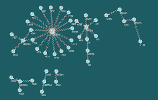

Con esto se puede realizar la busqueda de asociación de las variantes a una enfermedad.

# **Referencias bibiliográficas**

Bolger, A M, M Lohse, and B Usadel. 2014. “Trimmomatic: A Flexible Trimmer for Illumina Sequence Data.” Bioinformatics 30 (15): 2114–20. doi:btu170[pii]10.1093/bioinformatics/btu170.

Carelli, Valerio, Alessandra Maresca, Leonardo Caporali, Selena Trifunov, Claudia Zanna, and Michela Rugolo. 2015. “Mitochondria: Biogenesis and Mitophagy Balance in Segregation and Clonal Expansion of Mitochondrial DNA Mutations.” International Journal of Biochemistry and Cell Biology 63. Elsevier Ltd: 21–24. doi:10.1016/j.biocel.2015.01.023.

Damas, Joana, David C. Samuels, Joo Carneiro, Antonio Amorim, and Filipe Pereira. 2014. “Mitochondrial DNA Rearrangements in Health and Disease-A Comprehensive Study.” Human Mutation 35 (1): 1–14. doi:10.1002/humu.22452.

Li, H, B Handsaker, A Wysoker, T Fennell, J Ruan, N Homer, G Marth, G Abecasis, and R Durbin. 2009. “The Sequence Alignment/Map Format and SAMtools.” Bioinformatics 25 (16): 2078–79. doi:btp352 [pii]10.1093/bioinformatics/btp352.